# Metagenome Quality Control and Normalization

Published

5 Dec 2025

## Overview:

#### Quality Control and Normalization

1. **Step 1: Load data and meta data**  
   Load data and meta data and filter out any QC samples.
2. **Step 2: Filter low count samples**
3. **Step 3: Taxonomical-filtering**  
   Identify treshold for low abundant taxa to filter  
   Step 1. Split clade name into seperate columns  
   Step 2. Identify the strains to remove  
   Step 3. Aggregate removed strains by higher levels  
   Step 4. Get longer format and add back clade_names  
   Step 5. Subtract filtered taxa from each higher taxa levels  
   Step 6. Check for samples with total taxa < 60% after filtering  
   Step 7: Check and replace negative values with zero  
   Step 8: Re-normalize each sample to 100%
4. **Step 4: Simplify clade names**
5. **Step 5: Centered Log Ratio (CLR) Transformation**
6. **Step 6: Exploratory Unsupervised PCA**
7. **Step 7: Exploratory Heatmap**

### Load Libraries

```r
##################
# LOAD LIBRARIES #
##################
library(tidyverse)
library(mixOmics)
library(readxl)
library(cowplot)
library(RColorBrewer)
library(scales)
select <- dplyr::select
map <- purrr::map

#################
# COLOUR PALLET #
#################
pal <- c("#902267", "#ffa998", "#f588af", "gray") # #e05e85
pal2 <- c("#f26386", "#f588af",  "#a4d984", "#5f983cff", "#fbbc52", "#fd814e", "gray")

# setwd("/Users/vilkal/work/Brolidens_work/Projects/Candida-omics/src")

taxonomy <- c(
  "kingdom",
  "phylum",
  "class",
  "order",
  "family",
  "genus",
  "species",
  "strain"
)
```

The first part of this script follows the preprocessing steps outlined on the MixOmics tutorial https://mixomics.org/mixmc/mixmc-preprocessing/

## Step 1: Load data

```r
data_path <- "/Users/vilkal/work/Brolidens_work/Projects/Candida-omics/Tidy_data/Metagenomics/Metageonome_all_vagswab_metaphlan.csv"
count_info_vagswab_path <- "../Tidy_data/Metagenomics/Read_count_info_vaginalswab.csv"
meta_path <- "/Users/vilkal/Downloads/Metadata_svamp.xlsx"

#############
# LOAD DATA #
#############
data <- read_csv(data_path)
count_info_vagswab <- read_csv(count_info_vagswab_path)
meta_data <- read_xlsx(meta_path, sheet = "Metadata", skip = 1, na = "na")
```

```r
gr_data <- meta_data %>%
    rename(`Symptom score (0-5)` = "Symptom score (0-5) - ibland har de svarat olika skriftligt i frågeformuläret och muntligt vid inklusiion, då har jag valt den högsta scoren") %>%
  select(
    svamp_ID,
    `Clinical score (0-5)`,
    `Fungal culture: C. albicans (y/n)`,
    `Fungal culture: Non-albicans candida spp. (y/n)`,
    `Symptom score (0-5)`,
    `Recurring fungal infections > 2/year (y/n)`
  ) %>%
    mutate(
  group = case_when(
    `Fungal culture: C. albicans (y/n)` == "1" &
      `Symptom score (0-5)` >= 1 &
      `Recurring fungal infections > 2/year (y/n)` == "1" ~
      "RVVCpos",

    `Fungal culture: C. albicans (y/n)` == "0" &
      `Recurring fungal infections > 2/year (y/n)` == "1" ~
      "RVVCneg",

    `Fungal culture: C. albicans (y/n)` == "1" &
      `Symptom score (0-5)` == 0 ~
      "AS",

    `Fungal culture: C. albicans (y/n)` == "0" &
      `Recurring fungal infections > 2/year (y/n)` == "0" ~
      "Control",

    `Fungal culture: C. albicans (y/n)` == "1" &
      `Recurring fungal infections > 2/year (y/n)` == "0" ~
      "Candidapos",

    TRUE ~ NA_character_
  )
) %>%
  select("svamp_ID", group, everything())
```

## Step 2: Filter low count samples

```r
# Identify samples with low total reads < 20 million total reads (human + bacterial)
count_info_vagswab %>%
  filter(after_fastp < 20000000) %>% # 1 sample
  knitr::kable()
```

| Sample | barcode_shotgun_swab | DS_ID | svamp_ID | ID | duplication | before_fastp | after_fastp | after_kraken2_host_removal |
| --- | --- | --- | --- | --- | --- | --- | --- | --- |
| 242_MiKantarell__FF06581440__E200019430_L1_72_ | FF06581440 | K10 | S10 | S10 | 0.0004724 | 12701 | 12691 | 10805 |

```r
# check bacterial reads bellow 100k
count_info_vagswab %>%
  filter(after_kraken2_host_removal < 100000) %>%
  knitr::kable()
```

| Sample | barcode_shotgun_swab | DS_ID | svamp_ID | ID | duplication | before_fastp | after_fastp | after_kraken2_host_removal |
| --- | --- | --- | --- | --- | --- | --- | --- | --- |
| 242_MiKantarell__FF06581440__E200019430_L1_72_ | FF06581440 | K10 | S10 | S10 | 0.0004724 | 12701 | 12691 | 10805 |

```r
# remove samples with low read count
data <- data %>%
    select( -S10) # removes ctrl and extra samples
```

## Step 3: Taxonomical-filtering

```r
# final
############################
# IDENTIFY TAXA TO FILTER #
###########################
t <- set_names(taxonomy, seq_along(taxonomy))
data <- data %>%
    select( -contains("ex"), -contains("seq"), -contains("_run2"), -starts_with("KX")) %>% # removes ctrl and extra samples
    #select(-matches("_1W|_3M|_6M")) %>%
    mutate(
        level = factor(
            t[as.character(str_count(clade_name, "\\|") + 1)],
            levels = taxonomy),
            .after = "clade_name"
            )

n_samples <- select(data, starts_with("S")) %>% ncol() # number of good samples
n_samples
```

```
[1] 151
```

```r
# keep taxa with at least 0.005% in at least 6% (5 out of 84) of samples, or at least 2% relative abundance in at least 1 sample.

# --- Step 1. split clade name into seperate columns
temp <- data %>%
    separate(
    col = clade_name,
    into = taxonomy,
    sep = "\\|",
    #remove = FALSE,
    fill = "right"
  ) %>%
  # keeps any row where at least one numeric column has a value greater than zero
  filter(if_any(where(is.double), ~ .x > 0))

# --- Step 2. Identify the strains to remove
strains_to_remove <- temp %>%
  filter(level == "strain") %>%
  filter(
    !(rowSums(across(where(is.double), ~ .x > 0.005)) >=
      round(0.06 * n_samples) |
      rowSums(across(where(is.double), ~ .x >= 2)) >= 1)
  )

# pander table of strains to remove
strains_to_remove %>%
  arrange(desc(rowSums(across(where(is.numeric))))) %>%
  # removes samples with colsum = zero:
  select(
    -where(~ is.numeric(.x) && sum(.x) == 0)
  ) %>%
  knitr::kable(., digits = 1)
```

| kingdom | phylum | class | order | family | genus | species | strain | level | S02 | S03 | S04 | S05 | S09 | S14 | S17 | S18 | S20 | S22 | S23 | S24 | S25 | S27 | S29 | S30 | S31 | S32 | S35 | S37 | S38 | … |
| --- | --- | --- | --- | --- | --- | --- | --- | --- | --- | --- | --- | --- | --- | --- | --- | --- | --- | --- | --- | --- | --- | --- | --- | --- | --- | --- | --- | --- | --- | --- |
| k__Bacteria | p__Actinobacteria | c__Actinomycetia | o__Actinomycetales | f__Actinomycetaceae | g__GGB753 | s__GGB753_SGB989 | t__SGB989 | strain | 0.0 | 0.0 | 0 | 0.0 | 0 | 0.0 | 0.5 | 0 | 2.0 | 0 | 0 | 0.0 | 0.0 | 0.0 | 0 | 0.0 | 0 | 0.0 | 0.8 | 0 | 0.0 | … |
| k__Bacteria | p__Firmicutes | c__Bacilli | o__Lactobacillales | f__Lactobacillaceae | g__Limosilactobacillus | s__Limosilactobacillus_coleohominis | t__SGB7100 | strain | 0.0 | 0.0 | 0 | 0.0 | 0 | 0.4 | 0.0 | 0 | 0.0 | 0 | 0 | 0.0 | 0.0 | 0.0 | 0 | 0.0 | 0 | 0.0 | 0.0 | 0 | 0.0 | … |
| k__Bacteria | p__Actinobacteria | c__Actinomycetia | o__Bifidobacteriales | f__Bifidobacteriaceae | g__Bifidobacterium | s__Bifidobacterium_bifidum | t__SGB17256 | strain | 0.0 | 0.0 | 0 | 0.0 | 0 | 0.0 | 0.0 | 0 | 0.0 | 0 | 0 | 0.7 | 0.0 | 0.0 | 0 | 0.0 | 0 | 0.0 | 0.0 | 0 | 0.1 | … |
| k__Bacteria | p__Firmicutes | c__Clostridia | o__Eubacteriales | f__Peptostreptococcaceae | g__Peptostreptococcus | s__Peptostreptococcus_anaerobius | t__SGB746 | strain | 0.0 | 0.0 | 0 | 0.0 | 0 | 0.0 | 0.0 | 0 | 0.7 | 0 | 0 | 0.0 | 0.0 | 0.0 | 0 | 0.0 | 0 | 0.0 | 0.0 | 0 | 0.0 | … |
| k__Bacteria | p__Bacteroidota | c__Bacteroidia | o__Bacteroidales | f__Prevotellaceae | g__Prevotella | s__Prevotella_colorans | t__SGB1502 | strain | 0.0 | 0.0 | 0 | 0.0 | 0 | 0.0 | 0.1 | 0 | 0.0 | 0 | 0 | 0.6 | 0.0 | 0.0 | 0 | 0.0 | 0 | 0.0 | 0.0 | 0 | 0.0 | … |
| k__Bacteria | p__Fusobacteria | c__Fusobacteriia | o__Fusobacteriales | f__Leptotrichiaceae | g__Sneathia | s__Sneathia_sanguinegens | t__SGB6045 | strain | 0.0 | 0.0 | 0 | 0.0 | 0 | 0.0 | 0.6 | 0 | 0.6 | 0 | 0 | 0.0 | 0.0 | 0.0 | 0 | 0.0 | 0 | 0.0 | 0.0 | 0 | 0.5 | … |
| k__Bacteria | p__Firmicutes | c__Negativicutes | o__Veillonellales | f__Veillonellaceae | g__Veillonella | s__Veillonella_montpellierensis | t__SGB6960 | strain | 0.0 | 0.0 | 0 | 0.1 | 0 | 0.0 | 0.0 | 0 | 0.0 | 0 | 0 | 0.0 | 0.0 | 0.0 | 0 | 0.0 | 0 | 0.0 | 0.0 | 0 | 0.0 | … |
| k__Bacteria | p__Firmicutes | c__Bacilli | o__Lactobacillales | f__Lactobacillaceae | g__Lacticaseibacillus | s__Lacticaseibacillus_paracasei | t__SGB7142 | strain | 0.0 | 0.0 | 0 | 0.0 | 0 | 0.0 | 0.0 | 0 | 0.0 | 0 | 0 | 0.0 | 0.0 | 0.0 | 0 | 0.0 | 0 | 0.0 | 0.0 | 0 | 0.0 | … |
| k__Bacteria | p__Actinobacteria | c__Coriobacteriia | o__Coriobacteriales | f__Atopobiaceae | g__Atopobium | s__Atopobium_deltae | t__SGB988 | strain | 0.0 | 0.0 | 0 | 0.0 | 0 | 0.0 | 0.0 | 0 | 0.0 | 0 | 0 | 0.3 | 0.0 | 0.0 | 0 | 0.0 | 0 | 0.0 | 0.0 | 0 | 0.0 | … |
| k__Bacteria | p__Firmicutes | c__Tissierellia | o__Tissierellales | f__Peptoniphilaceae | g__Peptoniphilus | s__Peptoniphilus_vaginalis | t__SGB6696 | strain | 0.0 | 0.0 | 0 | 0.0 | 0 | 0.0 | 0.0 | 0 | 1.3 | 0 | 0 | 0.0 | 0.0 | 0.0 | 0 | 0.0 | 0 | 0.0 | 0.0 | 0 | 0.0 | … |
| k__Bacteria | p__Firmicutes | c__Bacilli | o__Lactobacillales | f__Lactobacillaceae | g__Limosilactobacillus | s__Limosilactobacillus_vaginalis | t__SGB7098 | strain | 0.7 | 0.0 | 0 | 0.0 | 0 | 0.0 | 0.0 | 0 | 0.0 | 0 | 0 | 0.0 | 0.0 | 0.0 | 0 | 0.0 | 0 | 0.0 | 0.0 | 0 | 0.0 | … |
| k__Bacteria | p__Firmicutes | c__Tissierellia | o__Tissierellales | f__Peptoniphilaceae | g__Peptoniphilus | s__Peptoniphilus_lacrimalis | t__SGB6705 | strain | 0.0 | 0.0 | 0 | 0.0 | 0 | 0.0 | 0.1 | 0 | 0.0 | 0 | 0 | 0.0 | 0.0 | 0.0 | 0 | 0.0 | 0 | 0.0 | 0.0 | 0 | 0.0 | … |
| k__Bacteria | p__Firmicutes | c__Tissierellia | o__Tissierellales | f__Peptoniphilaceae | g__Peptoniphilus | s__Peptoniphilus_coxii | t__SGB6734 | strain | 0.0 | 0.0 | 0 | 0.0 | 0 | 0.0 | 0.0 | 0 | 0.0 | 0 | 0 | 0.8 | 0.0 | 0.0 | 0 | 0.0 | 0 | 0.0 | 0.0 | 0 | 0.0 | … |
| k__Bacteria | p__Actinobacteria | c__Actinomycetia | o__Actinomycetales | f__Actinomycetaceae | g__GGB754 | s__GGB754_SGB990 | t__SGB990 | strain | 0.0 | 0.0 | 0 | 0.0 | 0 | 0.0 | 0.0 | 0 | 0.4 | 0 | 0 | 0.0 | 0.0 | 0.0 | 0 | 0.0 | 0 | 0.0 | 0.2 | 0 | 0.5 | … |
| k__Bacteria | p__Firmicutes | c__Bacilli | o__Bacillales | f__Bacillales_unclassified | g__Gemella | s__Gemella_asaccharolytica | t__SGB7308 | strain | 0.0 | 0.0 | 0 | 0.0 | 0 | 0.0 | 0.2 | 0 | 0.0 | 0 | 0 | 0.0 | 0.0 | 0.0 | 0 | 0.0 | 0 | 0.0 | 0.0 | 0 | 0.0 | … |
| k__Eukaryota | p__Ascomycota | c__Saccharomycetes | o__Saccharomycetales | f__Debaryomycetaceae | g__Candida | s__Candida_parapsilosis | t__EUK5480 | strain | 0.0 | 0.0 | 0 | 0.0 | 0 | 0.0 | 0.0 | 0 | 0.0 | 0 | 0 | 0.0 | 0.0 | 0.0 | 0 | 1.1 | 0 | 0.0 | 0.0 | 0 | 0.0 | … |
| k__Bacteria | p__Actinobacteria | c__Actinomycetia | o__Actinomycetales | f__Actinomycetaceae | g__Mobiluncus | s__Mobiluncus_curtisii | t__SGB15487 | strain | 0.0 | 0.0 | 0 | 0.0 | 0 | 0.0 | 0.1 | 0 | 0.0 | 0 | 0 | 0.0 | 0.0 | 0.0 | 0 | 0.0 | 0 | 0.0 | 0.0 | 0 | 0.0 | … |
| k__Bacteria | p__Bacteroidota | c__Bacteroidia | o__Bacteroidales | f__Prevotellaceae | g__Prevotella | s__Prevotella_sp_S7_1_8 | t__SGB1501 | strain | 0.0 | 0.0 | 0 | 0.0 | 0 | 0.0 | 0.0 | 0 | 0.0 | 0 | 0 | 0.0 | 0.0 | 0.0 | 0 | 0.0 | 0 | 0.0 | 1.0 | 0 | 0.0 | … |
| k__Bacteria | p__Firmicutes | c__Bacilli | o__Lactobacillales | f__Streptococcaceae | g__Streptococcus | s__Streptococcus_salivarius | t__SGB8007_group | strain | 0.0 | 0.1 | 0 | 0.0 | 0 | 0.0 | 0.0 | 0 | 0.0 | 0 | 0 | 0.0 | 0.6 | 0.0 | 0 | 0.0 | 0 | 0.0 | 0.0 | 0 | 0.0 | … |
| k__Bacteria | p__Firmicutes | c__Bacilli | o__Bacillales | f__Staphylococcaceae | g__Staphylococcus | s__Staphylococcus_epidermidis | t__SGB7865 | strain | 0.1 | 0.0 | 0 | 0.0 | 0 | 0.0 | 0.0 | 0 | 0.0 | 0 | 0 | 0.0 | 0.0 | 0.0 | 0 | 0.0 | 0 | 0.0 | 0.0 | 0 | 0.0 | … |
| k__Bacteria | p__Actinobacteria | c__Coriobacteriia | o__Coriobacteriales | f__Atopobiaceae | g__Lancefieldella | s__Lancefieldella_rimae | t__SGB985 | strain | 0.0 | 0.0 | 0 | 0.0 | 0 | 0.0 | 0.0 | 0 | 0.0 | 0 | 0 | 0.0 | 0.0 | 0.0 | 0 | 0.0 | 0 | 0.0 | 0.0 | 0 | 0.0 | … |
| k__Bacteria | p__Bacteroidota | c__Bacteroidia | o__Bacteroidales | f__Bacteroidales_unclassified | g__Bacteroidales_unclassified | s__Bacteroidales_bacterium_KA00251 | t__SGB3324 | strain | 0.0 | 0.0 | 0 | 0.0 | 0 | 0.0 | 0.0 | 0 | 0.0 | 0 | 0 | 0.0 | 0.0 | 0.0 | 0 | 0.0 | 0 | 0.0 | 0.0 | 0 | 0.0 | … |
| k__Bacteria | p__Firmicutes | c__Tissierellia | o__Tissierellales | f__Peptoniphilaceae | g__Anaerococcus | s__Anaerococcus_vaginalis | t__SGB29499 | strain | 0.0 | 0.0 | 0 | 0.0 | 0 | 0.0 | 0.0 | 0 | 0.0 | 0 | 0 | 0.0 | 0.0 | 0.0 | 0 | 0.0 | 0 | 0.0 | 0.0 | 0 | 0.0 | … |
| k__Bacteria | p__Firmicutes | c__Tissierellia | o__Tissierellales | f__Peptoniphilaceae | g__Anaerococcus | s__Anaerococcus_lactolyticus | t__SGB6669 | strain | 0.0 | 0.0 | 0 | 0.0 | 0 | 0.0 | 0.0 | 0 | 0.0 | 0 | 0 | 0.1 | 0.0 | 0.0 | 0 | 0.0 | 0 | 0.0 | 0.0 | 0 | 0.0 | … |
| k__Bacteria | p__Proteobacteria | c__Gammaproteobacteria | o__Enterobacterales | f__Enterobacteriaceae | g__Escherichia | s__Escherichia_coli | t__SGB10068 | strain | 0.0 | 0.0 | 0 | 0.0 | 0 | 0.0 | 0.0 | 0 | 0.0 | 0 | 0 | 0.0 | 0.0 | 0.0 | 0 | 0.0 | 0 | 0.0 | 0.0 | 0 | 0.0 | … |
| k__Bacteria | p__Bacteroidota | c__Bacteroidia | o__Bacteroidales | f__Prevotellaceae | g__Prevotella | s__Prevotella_veroralis | t__SGB1541 | strain | 0.0 | 0.0 | 0 | 0.0 | 0 | 0.0 | 0.0 | 0 | 0.0 | 0 | 0 | 0.0 | 0.0 | 0.0 | 0 | 0.0 | 0 | 0.0 | 0.0 | 0 | 0.0 | … |
| k__Bacteria | p__Actinobacteria | c__Actinomycetia | o__Bifidobacteriales | f__Bifidobacteriaceae | g__Bifidobacterium | s__Bifidobacterium_longum | t__SGB17248 | strain | 0.0 | 0.0 | 0 | 0.2 | 0 | 0.0 | 0.0 | 0 | 0.0 | 0 | 0 | 0.0 | 0.0 | 0.0 | 0 | 0.0 | 0 | 0.0 | 0.0 | 0 | 0.0 | … |
| k__Bacteria | p__Tenericutes | c__Tenericutes_unclassified | o__Mycoplasmoidales | f__Metamycoplasmataceae | g__Metamycoplasma | s__Metamycoplasma_hominis | t__SGB5926 | strain | 0.0 | 0.0 | 0 | 0.0 | 0 | 0.0 | 0.0 | 0 | 0.0 | 0 | 0 | 0.0 | 0.0 | 0.0 | 0 | 0.0 | 0 | 0.0 | 0.0 | 0 | 0.0 | … |
| k__Bacteria | p__Bacteroidota | c__Bacteroidia | o__Bacteroidales | f__Muribaculaceae | g__GGB1460 | s__GGB1460_SGB2023 | t__SGB2023 | strain | 0.0 | 0.0 | 0 | 0.0 | 0 | 0.0 | 0.0 | 0 | 0.2 | 0 | 0 | 0.0 | 0.0 | 0.0 | 0 | 0.0 | 0 | 0.0 | 0.0 | 0 | 0.0 | … |
| k__Bacteria | p__Actinobacteria | c__Actinomycetia | o__Actinomycetales | f__Actinomycetaceae | g__Winkia | s__Winkia_neuii | t__SGB17191 | strain | 0.0 | 0.0 | 0 | 0.0 | 0 | 0.0 | 0.0 | 0 | 0.0 | 0 | 0 | 0.0 | 0.0 | 0.0 | 0 | 0.0 | 0 | 0.0 | 0.0 | 0 | 0.0 | … |

[output cut: 156 more lines]

```r
# --- Step 3. Aggregate removed strains by higher levels
removed_all_lvls <- strains_to_remove %>%
  # pivot_longer(cols = where(is.double), names_to = "sample", values_to = "removed_abundance") %>%
  select(-level) %>%
  pivot_longer(
    cols = kingdom:strain,
    names_to = "level",
    values_to = "name"
  ) %>%
  nest(.by = c(level)) %>%
  mutate(
    data = purrr::map(
      data,
      ~ summarise(.x, across(where(is.double), ~ sum(.)), .by = c("name"))
    )
  ) %>%
  mutate(data = setNames(.[["data"]], .$level))

removed_all_lvls
```

```
# A tibble: 8 × 2
  level   data
  <chr>   <named list>
1 kingdom <tibble [2 × 152]>
2 phylum  <tibble [9 × 152]>
3 class   <tibble [17 × 152]>
4 order   <tibble [28 × 152]>
5 family  <tibble [46 × 152]>
6 genus   <tibble [81 × 152]>
7 species <tibble [175 × 152]>
8 strain  <tibble [186 × 152]>
```

```r
knitr::kable(removed_all_lvls$data[[2]], digits = 1)
```

| name | S01 | S02 | S03 | S04 | S05 | S06 | S07 | S08 | S09 | S11 | S12 | S13 | S14 | S15 | S16 | S17 | S18 | S19 | S20 | S21 | S22 | S23 | S24 | S25 | S26 | S27 | S28 | S29 | S30 | … |
| --- | --- | --- | --- | --- | --- | --- | --- | --- | --- | --- | --- | --- | --- | --- | --- | --- | --- | --- | --- | --- | --- | --- | --- | --- | --- | --- | --- | --- | --- | --- |
| p__Firmicutes | 0 | 0.8 | 0.1 | 0 | 0.1 | 0 | 0 | 0 | 0 | 0 | 0 | 0 | 0.5 | 0 | 0 | 0.3 | 0 | 0 | 2.0 | 0 | 0 | 0 | 1.0 | 0.8 | 0 | 0.4 | 0 | 0 | 0.0 | … |
| p__Actinobacteria | 0 | 0.0 | 0.0 | 0 | 0.2 | 0 | 0 | 0 | 0 | 0 | 0 | 0 | 0.0 | 0 | 0 | 0.6 | 0 | 0 | 2.8 | 0 | 0 | 0 | 1.6 | 0.0 | 0 | 0.0 | 0 | 0 | 0.0 | … |
| p__Bacteroidota | 0 | 0.0 | 0.0 | 0 | 0.0 | 0 | 0 | 0 | 0 | 0 | 0 | 0 | 0.1 | 0 | 0 | 0.1 | 0 | 0 | 0.3 | 0 | 0 | 0 | 0.6 | 0.0 | 0 | 0.0 | 0 | 0 | 0.0 | … |
| p__Tenericutes | 0 | 0.0 | 0.0 | 0 | 0.0 | 0 | 0 | 0 | 0 | 0 | 0 | 0 | 0.0 | 0 | 0 | 0.0 | 0 | 0 | 0.0 | 0 | 0 | 0 | 0.0 | 0.0 | 0 | 0.0 | 0 | 0 | 0.0 | … |
| p__Proteobacteria | 0 | 0.0 | 0.0 | 0 | 0.0 | 0 | 0 | 0 | 0 | 0 | 0 | 0 | 0.0 | 0 | 0 | 0.0 | 0 | 0 | 0.0 | 0 | 0 | 0 | 0.0 | 0.0 | 0 | 0.0 | 0 | 0 | 0.0 | … |
| p__Candidatus_Saccharibacteria | 0 | 0.0 | 0.0 | 0 | 0.0 | 0 | 0 | 0 | 0 | 0 | 0 | 0 | 0.0 | 0 | 0 | 0.0 | 0 | 0 | 0.0 | 0 | 0 | 0 | 0.0 | 0.0 | 0 | 0.0 | 0 | 0 | 0.0 | … |
| p__Fusobacteria | 0 | 0.0 | 0.0 | 0 | 0.0 | 0 | 0 | 0 | 0 | 0 | 0 | 0 | 0.0 | 0 | 0 | 0.6 | 0 | 0 | 0.6 | 0 | 0 | 0 | 0.0 | 0.0 | 0 | 0.0 | 0 | 0 | 0.0 | … |
| p__Ascomycota | 0 | 0.0 | 0.0 | 0 | 0.0 | 0 | 0 | 0 | 0 | 0 | 0 | 0 | 0.0 | 0 | 0 | 0.0 | 0 | 0 | 0.0 | 0 | 0 | 0 | 0.0 | 0.0 | 0 | 0.0 | 0 | 0 | 1.1 | … |
| p__Synergistetes | 0 | 0.0 | 0.0 | 0 | 0.0 | 0 | 0 | 0 | 0 | 0 | 0 | 0 | 0.0 | 0 | 0 | 0.0 | 0 | 0 | 0.0 | 0 | 0 | 0 | 0.0 | 0.0 | 0 | 0.0 | 0 | 0 | 0.0 | … |

```r
# --- Step 4. get longer format and add back clade_names
# function to get clade name
get_full_clade.fun <- function(df) {
  # This will add a new column called match_clade
  # with the full clade_name that ends with the string from tissue_renorm_filt$clade_name
  df %>%
    mutate(
      match_clade = map_chr(
        name,
        ~ {
          hit <- data$clade_name[str_detect(
            data$clade_name,
            paste0(.x, "$")
          )]
          if (length(hit) > 0) hit[1] else NA_character_
        }
      )
    ) %>%
    select(match_clade) %>%
    pull()
}

removals <- removed_all_lvls %>%
  unnest(cols = data) %>%
  mutate(clade_name = get_full_clade.fun(.))

#############################
# FILTER AT ALL TAXA LEVELS #
############################
# --- Step 5. Subtract from higher levels
data_filt <- data %>%
  # Join percentages to be subtracted
  left_join(
    select(removals, -name, -level),
    by = "clade_name",
    suffix = c("", "_rm")
  ) %>%
  # Subtract sample-wise values
  mutate(
    across(
      matches("^S\\d\\d$"),
      ~ .x - coalesce(get(paste0(cur_column(), "_rm")), 0)
    )
  ) %>%
  select(-ends_with("_rm"))

# --- Step 6. report any samples with less than 60% total taxa after filtering
data_filt %>%
  #select(clade_name, level, S10) %>%
  filter(level == "family") %>%
  select(-clade_name, -level) %>%
  colSums() %>% {. ->> colsums} %>% enframe() %>% arrange(value)
```

```
# A tibble: 151 × 2
   name  value
   <chr> <dbl>
 1 S39    81.8
 2 S20    87.2
 3 S60    94.1
 4 S35    96.4
 5 S17    96.6
 6 S24    96.9
 7 S62    97.3
 8 S46    97.8
 9 S56    98.6
10 S38    98.7
# ℹ 141 more rows
```

```r
colsums
```

```
      S01       S02       S03       S04       S05       S06       S07       S08
100.00000  99.21119  99.89741  99.93309  99.73252 100.00000 100.00000 100.00000
      S09       S11       S12       S13       S14       S15       S16       S17
 99.99000 100.00000 100.00000 100.00001  99.37898 100.00000 100.00001  96.56156
      S18       S19       S20       S21       S22       S23       S24       S25
 99.96235 100.00000  87.17431  99.99999  99.98596  99.97637  96.89939  99.21227
      S26       S27       S28       S29       S30       S31       S32       S33
100.00000  99.57125 100.00000  99.99177  98.87746  99.97594  99.94326 100.00000
      S34       S35       S36       S37       S38       S39       S40       S41
100.00000  96.41933 100.00000  99.95414  98.69452  81.82923  99.99999 100.00000
      S42       S43       S44       S45       S46       S47       S48       S49
100.00001  99.91368  99.06419 100.00001  97.78572  99.89993 100.00000  99.99377
      S50       S51       S52       S53       S54       S55       S56       S57
100.00000  99.99325  99.66001  99.90956  99.95529  99.99396  98.63769 100.00000
      S58       S59       S60       S61       S62    S63_1W    S63_BL    S64_1W
100.00000 100.00001  94.13800  99.24552  97.30132  99.99999  99.98308  99.99999
   S64_3M    S64_6M    S64_BL    S65_1W    S65_3M    S65_BL    S66_1W    S66_3M
100.00001 100.00000 100.00000 100.00000  99.95931 100.00000 100.00000 100.00000
   S66_BL    S67_1W    S67_BL    S68_BL    S69_1W    S69_3M    S69_6M    S69_BL
 99.99999 100.00000 100.00000 100.00000 100.00000  99.99999 100.00000 100.00000
   S70_1W    S70_3M    S70_6M    S70_BL    S71_1W    S71_BL    S72_1W    S72_3M
100.00000  99.99999 100.00000 100.00001 100.00000 100.00000 100.00000 100.00000
   S72_6M    S72_BL    S73_1W    S73_3M    S73_6M    S73_BL    S74_1W    S74_3M
100.00001 100.00000  99.99999  99.99999  99.99999 100.00000 100.00000 100.00000
   S74_6M    S74_BL    S75_1W    S75_3M    S75_6M    S75_BL    S76_1W    S76_3M
100.00001 100.00000 100.00000 100.00000 100.00000 100.00000 100.00000 100.00000
   S76_6M    S76_BL    S77_1W    S77_3M    S77_BL    S78_1W    S78_3M    S78_6M
100.00001 100.00000 100.00000 100.00000 100.00001 100.00000 100.00000 100.00001
   S78_BL    S79_1W    S79_3M    S79_6M    S79_BL    S80_BL    S81_BL    S82_1W
 99.99999 100.00000 100.00000 100.00000 100.00000 100.00000 100.00000 100.00001
   S82_3M    S82_6M    S82_BL    S83_1W    S83_3M    S83_6M    S83_BL    S84_BL
100.00000 100.00000  99.99999 100.00000  99.99999 100.00001 100.00001 100.00002
   S85_1W    S85_3M    S85_6M    S85_BL    S86_1W    S86_BL    S87_1W    S87_3M
100.00000 100.00000 100.00001 100.00000 100.00001 100.00001 100.00001  99.99999
   S87_6M    S87_BL    S88_BL    S89_1W    S89_3M    S89_6M    S89_BL    S90_1W
100.00000 100.00000 100.00000 100.00000 100.00001 100.00000 100.00000 100.00000
   S90_3M    S90_6M    S90_BL    S91_1W    S91_3M    S91_6M    S91_BL
100.00000 100.00000 100.00000 100.00000 100.00000 100.00000 100.00000
```

```r
colsums[colsums <= 60]
```

```
named numeric(0)
```

```r
# --- Step 7: check and replace negatives ---
indx <- which(data_filt < 0, arr.ind = TRUE)
if (nrow(indx) > 0) {
  neg_report <- tibble(
    neg    = map2_dbl(indx[,1], indx[,2], ~ data_filt[[.x, .y]]),
    remove = map2_dbl(indx[,1], indx[,2], ~ data[[.x, .y]]),  # original value from data
    col    = map_chr(indx[,2], ~ colnames(data)[.x]),         # column name
    tax    = map_chr(indx[,1], ~ data[[.x, 1]])               # taxon/clade name
  )

  message("Negative values found and replaced with 0:")
  print(neg_report)

  # --- Step 7: replace negatives with zero ---
  data_filt <- data_filt %>%
  mutate(across(where(is.numeric), ~ pmax(.x, 0)))
}
```

```
Negative values found and replaced with 0:
```

```
# A tibble: 9 × 4
         neg remove col   tax
       <dbl>  <dbl> <chr> <chr>
1 -0.0000100 0.0159 S25   k__Bacteria|p__Firmicutes|c__Negativicutes
2 -0.0000100 0.0159 S25   k__Bacteria|p__Firmicutes|c__Negativicutes|o__Veillon…
3 -0.0000100 0.0159 S25   k__Bacteria|p__Firmicutes|c__Negativicutes|o__Veillon…
4 -0.0000100 0.0159 S25   k__Bacteria|p__Firmicutes|c__Negativicutes|o__Veillon…
5 -0.0000100 0.0312 S53   k__Bacteria|p__Firmicutes|c__Negativicutes
6 -0.0000100 0.0312 S53   k__Bacteria|p__Firmicutes|c__Negativicutes|o__Veillon…
7 -0.0000100 0.0312 S53   k__Bacteria|p__Firmicutes|c__Negativicutes|o__Veillon…
8 -0.0000100 0.0147 S54   k__Bacteria|p__Firmicutes|c__Tissierellia|o__Tissiere…
9 -0.0000100 0.145  S61   k__Bacteria|p__Actinobacteria|c__Actinomycetia|o__Cor…
```

```r
# test
strains_to_remove %>% pull("S39") %>% sum(.)
```

```
[1] 5.2491
```

```r
data_filt %>% filter(level == "genus") %>% pull("S39") %>% sum(.)
```

```
[1] 94.75088
```

```r
#####################################
# RENORMALIZED FILTERED TAXA VALUES #
#####################################
# --- Step 8. Re-normalize so each sample sums to 100
data_filt_norm <- data_filt %>%
  group_by(level) %>%
  mutate(
    across(
      matches("^S\\d\\d$"),
      ~ .x * 100 / sum(.x, na.rm = TRUE)
    )
  ) %>%
  ungroup()

# test
data_filt_norm %>% filter(level == "genus") %>% pull("S39") %>% sum(.)
```

```
[1] 100
```

### Save filtered table

```r
data_filt_norm %>%
  #select(-Pos_Seq_Ctrl) %>%
  arrange(level) %>%
  write_csv(
    .,
    "../Results/MixOmic/Metageonome_all_vagswab_metaphlan_taxa_filt.csv"
  )

data_filt_norm
```

```
# A tibble: 682 × 153
   clade_name  level     S01   S02     S03     S04     S05     S06     S07   S08
   <chr>       <fct>   <dbl> <dbl>   <dbl>   <dbl>   <dbl>   <dbl>   <dbl> <dbl>
 1 k__Bacteria king… 100       100 1   e+2 100     1   e+2 1.00e+2 1.00e+2 100
 2 k__Eukaryo… king…   0         0 0         0     0       3.54e-3 2.99e-2   0
 3 k__Bacteri… phyl…   0.304     0 8.22e-3   0.154 3.26e-2 5.14e-1 6.55e-2  19.6
 4 k__Eukaryo… phyl…   0         0 0         0     0       3.54e-3 2.99e-2   0
 5 k__Bacteri… phyl…  99.7     100 1.00e+2  99.8   1.00e+2 9.95e+1 9.99e+1  80.4
 6 k__Bacteri… class   0.304     0 8.22e-3   0.154 3.26e-2 5.14e-1 6.55e-2  19.6
 7 k__Eukaryo… class   0         0 0         0     0       3.54e-3 2.99e-2   0
 8 k__Bacteri… class  99.6     100 1.00e+2  99.7   1.00e+2 9.95e+1 9.99e+1  80.4
 9 k__Bacteri… order   0.304     0 8.22e-3   0.154 3.26e-2 5.14e-1 6.55e-2  19.6
10 k__Eukaryo… order   0         0 0         0     0       3.54e-3 2.99e-2   0
# ℹ 672 more rows
# ℹ 143 more variables: S09 <dbl>, S11 <dbl>, S12 <dbl>, S13 <dbl>, S14 <dbl>,
#   S15 <dbl>, S16 <dbl>, S17 <dbl>, S18 <dbl>, S19 <dbl>, S20 <dbl>,
#   S21 <dbl>, S22 <dbl>, S23 <dbl>, S24 <dbl>, S25 <dbl>, S26 <dbl>,
#   S27 <dbl>, S28 <dbl>, S29 <dbl>, S30 <dbl>, S31 <dbl>, S32 <dbl>,
#   S33 <dbl>, S34 <dbl>, S35 <dbl>, S36 <dbl>, S37 <dbl>, S38 <dbl>,
#   S39 <dbl>, S40 <dbl>, S41 <dbl>, S42 <dbl>, S43 <dbl>, S44 <dbl>, …
```

```r
# data_filt_norm <- read_csv("../Results/Tissue_QC/Metageonome_all_vagswab_metaphlan_taxa_filt.csv")
```

For technical, biological and computational reasons, microbiome data is compositional such that they represent proportions or relative information. Proportional data are restricted to a space where the sum of all OTU proportions for a given sample sums to 1. Using standard statistical methods on such data may lead to spurious results. Likewise, any data that are compositional in nature are interpreted into relative counts. Hence, using a CLR transformation allows the circumvention of these spurious results.

There are two ways of log-ratio transforming the data in mixOmics:

- Option 1: Some of our functions (pca, plsda) directly include the argument logratio = ‘CLR’, so all you need to do is include your filtered offset data and add this argument (see example below).
- Option 2: Some functions currently do not include the logratio argument. In this case, you will need to use the logratio.transfo() function as shown below. You can also use this function if you only have access to TSS (proportions) data and those were not offset.

unlike 16S data which are returned as raw counts after pre-processing, shotgun metageome data is often already normalized into proportions. This is because direct counts aren’t very meaningful across different taxa/genomes. That is why we will go with option 2 for our data.

### Shotgun metagenomics

- You sequence **all DNA** in the sample, not just one marker gene.
- Reads are mapped to **reference genomes, genes, or functional categories**.
- Raw counts can be biased by factors like:
  - genome size
  - gene length
  - variable sequencing depth
- Because of this, many sequencing facilities preprocess shotgun data to produce **normalized relative abundances (proportions)**, so that samples can be compared more easily.

**Typical outputs include:**  
- Relative abundance (%) of taxa  
- RPKM / TPM / CPM for genes or functions

Now we want to simplify the `clade_name` column so that:

- For **phylum / class / order / family / genus**, only the relevant level is kept.
- For **species** and **strain**, all levels are incuded down from genus,  
  i.e. `"Genus species"` or `"Genus species strain"`.

```r
# string manipulation

# data_filt_norm <- read_csv("../Results/Tissue_QC/Metageonome_all_vagswab_metaphlan_taxa_filt.csv")

# Modify taxa labels
data_filt_norm <- data_filt_norm %>%
  mutate(
    taxa = str_extract_all(clade_name, "(?<=k__|p__|c__|o__|f__|g__|s__|t__)[^|]+"),
    taxa = map2_chr(taxa, level, ~ {
      if (.y %in% c("species", "strain")) {
        # keep everything from genus onward
        start <- which(c("k","p","c","o","f","g","s","t") %in% substr(.y,1,1))
        paste(.x[start:length(.x)], collapse = " ")
      } else {
        # keep only the last element (current level)
        tail(.x, 1)
      }
    }),
    .after = "level"
  ) %>%
  select(-clade_name) %>%
  rename(clade_name = taxa)
```

## Step 5: Centered Log Ratio (CLR) Transformation

```r
# Create matrix for all levels of taxa
# NB! the majority(?) of mixOmics functions expect a format of
# samples as rows and features as columns, thus the transformation
# is VERY important!
matrix <- data_filt_norm %>%
    #rename_with(~ str_replace(.x, "_BL$", ""), everything()) %>%
    nest(data = -level) %>%
    # filter(level == "strain") %>%
    mutate(
    data = map(
      data,
      ~ .x %>%
        column_to_rownames(var = "clade_name") %>%
        as.matrix() %>%
        t()
    )
  )

matrix
```

```
# A tibble: 8 × 2
  level   data
  <fct>   <list>
1 kingdom <dbl [151 × 2]>
2 phylum  <dbl [151 × 10]>
3 class   <dbl [151 × 20]>
4 order   <dbl [151 × 31]>
5 family  <dbl [151 × 56]>
6 genus   <dbl [151 × 99]>
7 species <dbl [151 × 220]>
8 strain  <dbl [151 × 244]>
```

```r
# Specify levels you want to process
tax_levels <- c("order", "family", "genus", "species", "strain")


matrix <- matrix %>%
  # Apply CLR transformation and PCA to each level
  mutate(
    clr_data = map(data, ~ logratio.transfo(.x, logratio = "CLR", offset = 1))
  ) %>%
    mutate(across(2:3, ~set_names(.x, paste0(.data[["level"]]))))
```

```r
 matrix %>%
  select(1,clr_data) %>%
  saveRDS(
  .,
    "../Results/MixOmic/Metageonome_vagswab_CLR_transformed.RDS"
  )
# matrix <- read_csv("../Results/MixOmic/Metageonome_vagswab_CLR_transformed.csv")
```

## Step 6: Exploratory Unsupervised PCA

```r
g <- c("0"="0-1", "1"="0-1", "2"="2-3", "3"="2-3", "4"="4-5", "5"="4-5")
gr <- tibble(ID = colnames(data)[-c(1,2)]) %>%
    left_join(., gr_data, by =c("ID"="svamp_ID")) %>%
    mutate(
      pos = case_when(
        `Fungal culture: C. albicans (y/n)` == "1" |
        `Fungal culture: Non-albicans candida spp. (y/n)` == 1 ~
        "pos",
        TRUE ~ "neg"
        ), .after="group") %>%
    mutate(`Clinical score (0-5)` = as.character(.$`Clinical score (0-5)`)) %>%
    mutate(Clin_gr = g[.$`Clinical score (0-5)`], .after ="group") #%>%
    #filter(!(is.na(.$Clin_gr)))
```

```r
matrix <- matrix %>%
  # Filter matrix to only these levels
  filter(level %in% tax_levels) %>%

  # Apply CLR transformation and PCA to each level
  mutate(
    #clr_data = map(data, ~ logratio.transfo(.x, logratio = "CLR", offset = 1)),
    pca_res  = map(clr_data, ~ pca(.x)),
    plot = map2(pca_res, level, ~plotIndiv(.x, col = pal,
                group = gr$Clin_gr, ind.names = F, size.title = 9,
                title = paste0(.y))),
    plot2 = map2(pca_res, level, ~plotIndiv(.x, col = pal2,
                group = gr$`Clinical score (0-5)`, ind.names = F, size.title = 9,
                title = paste0(.y)))
  ) %>%
    mutate(across(2:5, ~set_names(.x, paste0(.data[["level"]]))))
```

```r
# Plot PCA for selected levels
l <- get_legend(plotIndiv(matrix$pca_res[["genus"]], col = pal, legend = T, group = gr$Clin_gr)$graph)
```

```r
l2 <- get_legend(plotIndiv(matrix$pca_res[["genus"]], col = pal2, legend = T, group = gr$`Clinical score (0-5)`)$graph)
```

```r
p <- matrix$plot %>% map("graph")
p2 <- matrix$plot2 %>% map("graph")
```

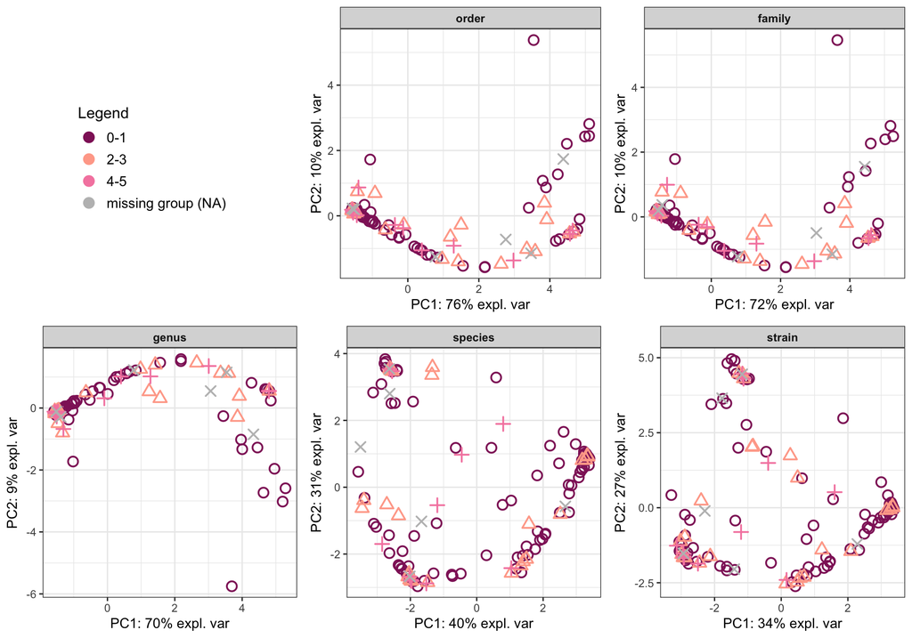

```r
plot_grid(
  plotlist = c(list(l),p),
  #labels = matrix$level,   # use taxonomy levels as labels
  ncol = 3
)
```

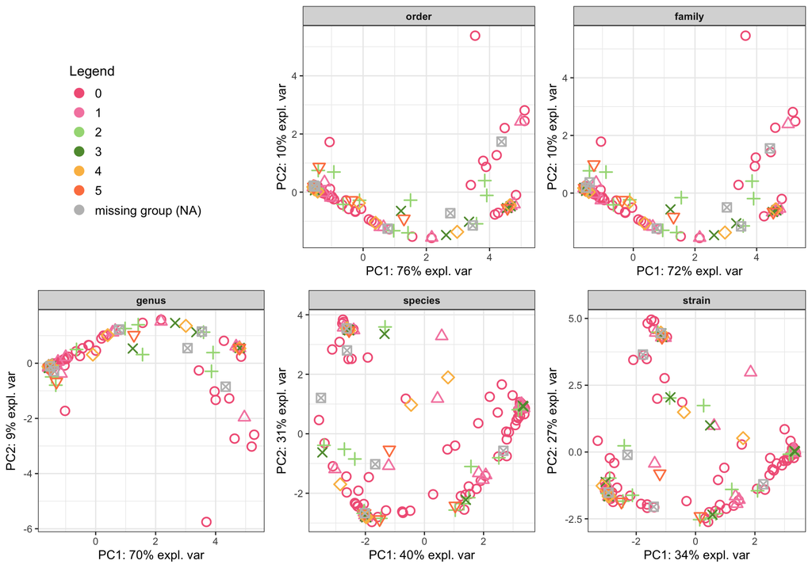

```r
plot_grid(
  plotlist = c(list(l2),p2),
  #labels = matrix$level,   # use taxonomy levels as labels
  ncol = 3
)
```

There are no clear seperation between the labels at any of the taxa levels. A google search indicate that Some studies find family or genus level is often most informative. Im wondering weather I can combine the matrix for genus and species level and to the PLS-DA on that?

Now that the data is:

- filtered for low abundant taxa
- CLR transformed
- offset added

Now we can move on to the Feature selection (PLS-DA) For this portion of the script we are following the MixOmics tutorial here: https://mixomics.org/mixmc/koren-bodysites-case-study/

## Step 7: Exploratory Heatmap

```r
library(ComplexHeatmap)
library(circlize)
# no need to scale or center abundance data as this inherently in percent:
# we only need to log transforme the data and add a off-set
# I dont know if it is more appropriate to use abundanc or CLR normalized data

# CLR
matrix.h <-  matrix$clr_data$species %>% t()

# log abundance
# matrix.h <- matrix.h + 0.0001 %>% log2()

# Filter
matrix.h <- matrix.h[,gr$ID]

top <- sort(rowSums(t(matrix$data$species)), decreasing = T)[1:50]
matrix.h <- matrix.h[names(top),]

dim(matrix.h)
```

```
[1]  50 151
```

```r
##############
# ANNOTATION #
##############
# colour pallets
blue <- brewer.pal(6, name = "Blues")
purple <- brewer.pal(6, name = "Purples")
reds <- brewer.pal(6, name = "Reds")

Red <- brewer.pal(6, name = "Reds") %>% c(., "gray")
pal <- c("#f26386",  "#a4d984", "#fbbc52", "gray") # "#f588af", "#fd814e"
pal2 <- c("#2266ac", "#91c5de", "gray")

# group information
cols <- c("Clin_gr", "Clinical score (0-5)", "Fungal culture: C. albicans (y/n)") %>% set_names()
lvls <- map(cols, ~ c(sort(unique(gr[[.x]])), "na"))

annot_col <- gr %>%
  mutate(across(all_of(cols),
                ~ factor(.x, levels = lvls[[cur_column()]])))

# check samples number
dim(matrix.h)
```

```
[1]  50 151
```

```r
dim(annot_col)
```

```
[1] 151   9
```

```r
# top annotation object:
top_annot <- columnAnnotation(
  Groups = annot_col$Clin_gr,
  Clin = annot_col$`Clinical score (0-5)`,
  Culture = annot_col$`Fungal culture: C. albicans (y/n)`,
  #show_legend = FALSE,
  show_annotation_name = T,
  annotation_name_gp = gpar(fontsize = 8),
  annotation_legend_param = list(
    grid_height = unit(.1, "mm"),
    grid_width = unit(2, "mm"),
    title = "", labels_gp = gpar(fontsize = 7),
    title_gp = gpar(fontsize = 8)),
  simple_anno_size = unit(.3, "cm"),
  #gap = unit(1, "cm"),
  col=list( Clin=set_names(Red, levels(annot_col$`Clinical score (0-5)`)),
            Groups=set_names(pal, levels(annot_col$Clin_gr)),
            Culture=set_names(pal2, levels(annot_col$`Fungal culture: C. albicans (y/n)`)))
            )
```

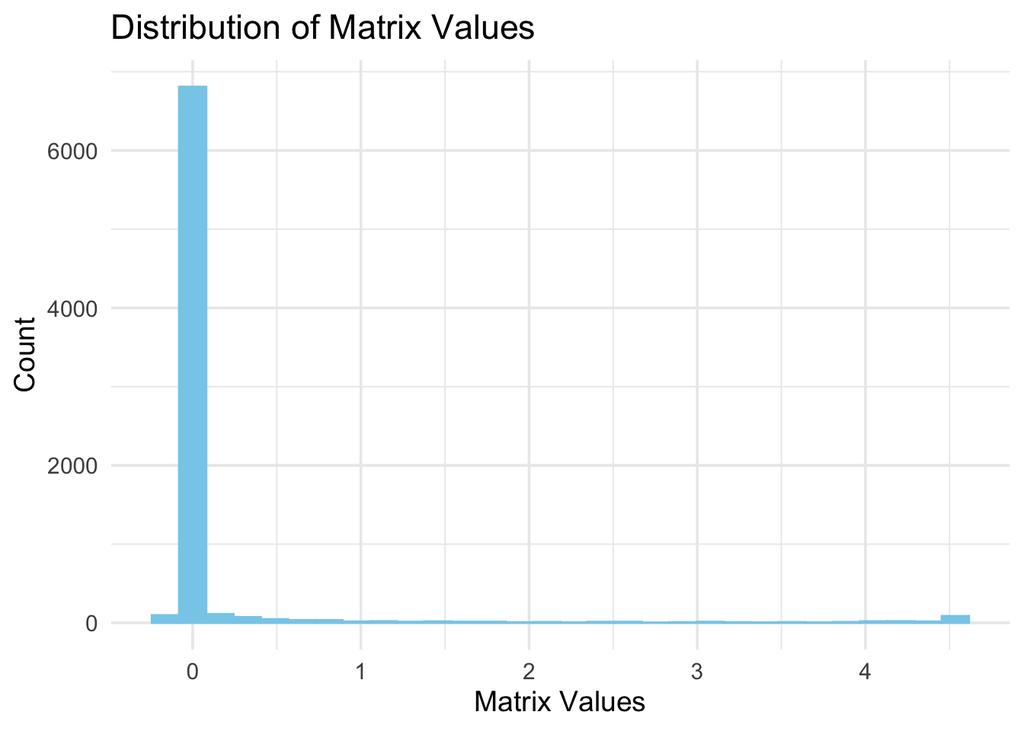

```r
################
# PLOT HEATMAP #
################
# colour mapping
breaks.fun <- function(min, max, n){
  x <- seq(min, max, length.out = n)
  x[which(x == median(x))] <- 0
  round(x)
  return(x)}

q <- quantile(matrix.h, probs = seq(0, 1, 0.1))
# to better know what values to use for the legend
# we use the quantile() function to get appropriate limits
# we plot the distribution of values
# Convert to a data frame for ggplot
df <- data.frame(value = as.vector(matrix.h))

# Basic ggplot histogram
ggplot(df, aes(x = value)) +
  geom_histogram( fill = "skyblue", color = "skyblue") +
  #scale_x_continuous(breaks = scales::breaks_pretty(n = 20)) +
  #scale_y_continuous(labels = label_comma()) + # <-- commas
  labs(
    title = "Distribution of Matrix Values",
    x = "Matrix Values",
    y = "Count"
  ) +
  theme_minimal(base_size = 14)
```

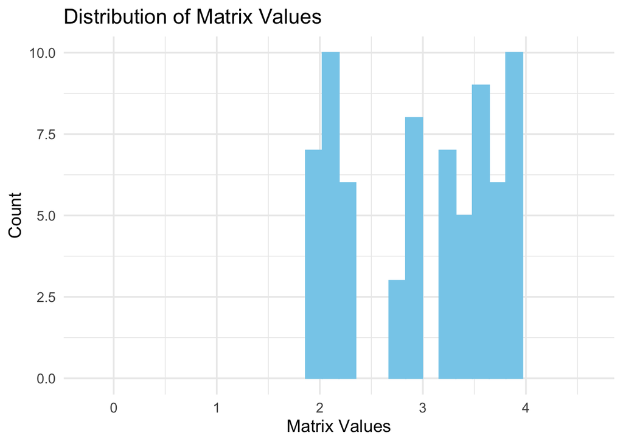

```r
# plot to better see the outlier values
ggplot(df, aes(x = value)) +
  geom_histogram(fill = "skyblue", color = "skyblue") +
  #scale_x_continuous(breaks = scales::breaks_pretty(n = 20)) +
  labs(
    title = "Distribution of Matrix Values",
    x = "Matrix Values",
    y = "Count"
  )  + ylim(0,10) +
  theme_minimal(base_size = 14)
```

```r
# set limits for colourpallet
RdBu = c("#364B9A", "#4A7BB7", "#6EA6CD", "#98CAE1", "#C2E4EF", "white", "#FEDA8B", "#FDB366", "#F67E4B", "#DD3D2D", "#A50026")

# using min and max from the matrix matrix can work, but is usualy influenced too much
# from the min and max values which tend to be outliers
# col <- colorRamp2(breaks.fun(min(matrix.h), max(matrix.h), 7), colorRampPalette(c(RdBu))(7))

# instead we use the historgram to determine the min and max values of the scale
# values larger than 5 are all mapped to dark red and values less than -5 are all mapped to dark blue.
# col <- colorRamp2(breaks.fun(q["25%"], -q["25%"], 7), colorRampPalette(c(RdBu))(7))
```

based on these histograms we can set the scale max and min breaks at 5

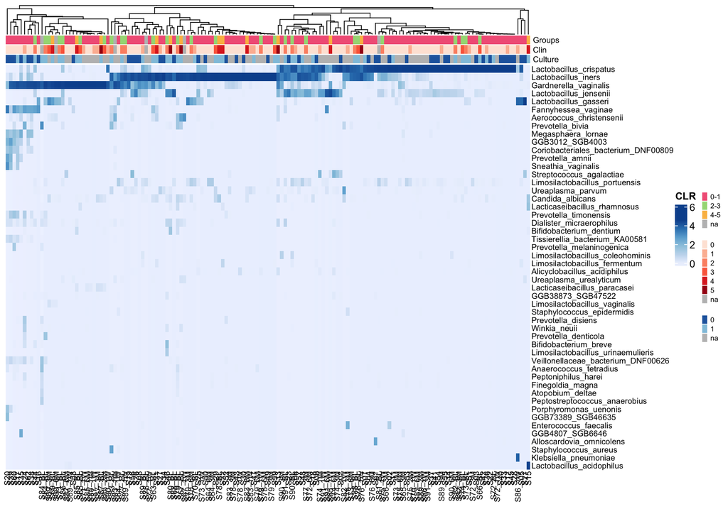

```r
################
# PLOT HEATMAP #
################
# Heatmap global options:
ht_opt$COLUMN_ANNO_PADDING = unit(.05, "cm")
ht_opt$HEATMAP_LEGEND_PADDING = unit(-0, "cm") #unit(c(0, 0, 0, -1), "cm") #b,l,t,r
ht_opt$TITLE_PADDING = unit(.05, "cm")
ht_opt$DIMNAME_PADDING = unit(.05, "cm")

# average expression:
H <- Heatmap(matrix.h,
             col = blue,
             cluster_columns = TRUE,
             show_row_dend = FALSE,
             name="CLR",
             show_row_names = T,
             show_column_names = TRUE,
             column_names_gp = grid::gpar(fontsize = 8),
             row_names_gp = grid::gpar(fontsize = 8),

            # annotation
             # right_annotation = right_anno_row, left_annotation = left_anno_row,
             top_annotation = top_annot
                                          )
H
```

```r
pdf(file = "./Heatmap_gene_expression.pdf", width = 10, height = 7)
H
dev.off()
```